# Chi-squared Pearson dispersion test with approximated methods for residual degrees of freedom in GLMMs

# Explanations

**package: glmmrBase** https://cran.r-project.org/web/packages/glmmrBase/index.html

**website (out of date)**: https://samuel-watson.github.io/glmmr-web/

**preprint about the package (2024)**: https://arxiv.org/abs/2303.12657

**mantainer**: Samuel Watson - Prof stats Uni Birmingham https://www.birmingham.ac.uk/staff/profiles/applied-health/watson-sam

To create the Chi-squared Pearson test with the approximate residual degrees of freedom, I first:

- converted the `lme4` function to the `glmmrBase` function
- and used the method `small-sample_correction()` to have the degrees of freedom (df) correction:
  - Kenward-Roger
  - Kenward-Roger2
  - Satterthwaithe
- I subtracted the sample size from this df to have the residual df.
- I used two.sides test.

From [Watson 2024](https://arxiv.org/abs/2303.12657): “The degrees of freedom correction is also given in Kenward and Roger (1997), which is the same degrees of freedom correction originally proposed by Satterthwaite (1946). The Kenward-Roger correction, though, can over-estimate the standard errors in very small samples in some cases. Kenward and Roger (2009) proposed an improved correction for covariance functions not linear in parameters (such as the autoregressive or exponential functions). The improved correction adds an additional adjustment factor. We have implemented these corrections in the package, which can returned directly from a Model object using the small_sample_correction() member function.”

The function:

```
approximateDFpearson <- function(model, data, type=c("naive", "KR", "KR2", "sat"),
                              alternative=c("two.sided", "greater", "less")){

  if(class(model)[1] != "glmerMod") stop("model is not a glmerMod from lme4")
  if(model@resp$family$family != "poisson") stop("model is not a Poisson")

  if(type == "naive"){
    rdf <- df.residual(model)
    } else{
    f1 <- glmmrBase::lme4_to_glmmr(formula(model), colnames(data))
    mod <- glmmrBase::Model$new(f1, data=data, family=poisson())
    rdf <- dim(data)[1]- mod$small_sample_correction(type)$dof[1]
    }

  rp <- residuals(model, "pearson")
  Pearson.chisq <- sum(rp^2)
  prat <- Pearson.chisq/rdf

  if(alternative == "greater") pval <- pchisq(Pearson.chisq, df=rdf, lower.tail=FALSE)
  else if (alternative == "less") pval <- pchisq(Pearson.chisq, df=rdf, lower.tail=TRUE)
  else if (alternative == "two.sided") pval <- min(min(pchisq(Pearson.chisq, df=rdf, lower.tail=TRUE), pchisq(Pearson.chisq, df=rdf, lower.tail=FALSE)) * 2,1)

  out = list()
  out$statistic = prat
  names(out$statistic) = "dispersion"
  out$parameter = rdf
  names(out$parameter) = paste0("df-",type)
  out$method = "Parametric dispersion test via mean Pearson-chisq statistic"
  out$alternative = alternative
  out$p.value = pval
  class(out) = "htest"
  return(out)
}
```

```r
source(here("functions_others", "approximateDFpearson.R"))
```

# Loading simulation outputs

Simulations done in `8_glmm_approxiDFpearson.R`:

Sim setting:

```r
sampleSize <- c(200, 500, 1000)
intercept <- c(-1.5,0,1.5)
overdispersion = seq(0,1,0.1)
ngroups <-  c(10, 50, 100)
nRep = 1000
slope = 1
randomEffectVariance = 1
```

```r
load(here("data", "8_approximateDFpearson.Rdata")) # simulated data
(tspent <- map_dbl(out.pois, "time")) # minutes
```

```
##   10_200_-1.5      10_200_0    10_200_1.5   10_500_-1.5      10_500_0
##      1.321605      1.219799      1.216456      2.353973      2.326321
##    10_500_1.5  10_1000_-1.5     10_1000_0   10_1000_1.5   50_200_-1.5
##      2.370980      8.441990      8.488686      8.568489      1.519092
##      50_200_0    50_200_1.5   50_500_-1.5      50_500_0    50_500_1.5
##      1.471159      1.405490      3.685771      6.909883      3.672749
##  50_1000_-1.5     50_1000_0   50_1000_1.5  100_200_-1.5     100_200_0
##     16.131561     16.184664     16.255666      1.805094      1.823181
##   100_200_1.5  100_500_-1.5     100_500_0   100_500_1.5 100_1000_-1.5
##      1.689025      5.617923      5.463803      5.451093     28.755045
##    100_1000_0  100_1000_1.5
##     31.243332     28.750171
```

```r
#simulations
simuls.pois <- map_dfr(out.pois, "simulations", .id="model") %>%
  separate(model, c("ngroups", "sampleSize", "intercept"), sep="_") %>%
  rename(overdispersion = controlValues,
        PearNaive.rdf = PearNaive.rdf.df.naive,
        PearSat.rdf = PearSat.rdf.df.sat,
        PearKR.rdf = PearKR.rdf.df.KR,
        PearKR2.rdf = PearKR2.rdf.df.KR2)
```

There were many negative residual dfs, it generates NaN to the test:

```r
simuls.nan <- simuls.pois %>% filter(PearSat.rdf < 0 |
                                     PearKR.rdf  < 0 |
                                     PearKR2.rdf < 0)
```

It was around 6% of the simulations.

Almost everything came from the 100 groups in 200 sample sizes - 2 observations per group:

```r
table(simuls.nan$ngroups, simuls.nan$sampleSize)
```

```
##
##         200   500
##   100 15567   392
##   50   1572     0
```

The percentage of failure was around the same among the corrections

```r
sum(simuls.nan$PearSat.rdf <0) / dim(simuls.pois)[1]
```

```
## [1] 0.02415152
```

```r
sum(simuls.nan$PearKR.rdf <0) / dim(simuls.pois)[1]
```

```
## [1] 0.02332997
```

```r
sum(simuls.nan$PearKR2.rdf <0) / dim(simuls.pois)[1]
```

```
## [1] 0.02317508
```

Subseting the simulation output only for the positive residual dfs:

```r
simuls.pois2 <- simuls.pois %>% filter(PearSat.rdf > 0 &
                                                       PearKR.rdf >0  &
                                                       PearKR2.rdf >0)
```

# Comparing corrections of residual df

```r
dof <- simuls.pois2 %>% dplyr::select(contains("rdf"), replicate, ngroups,
                                        overdispersion, intercept, sampleSize) %>%
  pivot_longer(1:4, names_to = "test", values_to = "res.df") %>%
  group_by(sampleSize, ngroups, intercept,overdispersion, test)
dof$intercept <- fct_relevel(dof$intercept, "-1.5", "0", "1.5")
dof$ngroups <- fct_relevel(dof$ngroups, "10", "50", "100")
dof$sampleSize <- as.factor(as.numeric(dof$sampleSize))
```

Very similar rdfs. Satterthwaite had a bit smaller rdfs for small sample size.

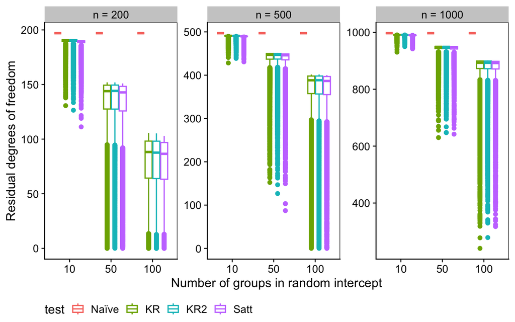

# Type I error

```r
p.pois <- simuls.pois2 %>% dplyr::select(ends_with(".p"), replicate,
                                        ngroups,
                                        overdispersion, intercept, sampleSize) %>%
  pivot_longer(1:4, names_to = "test", values_to = "p.val") %>%
  group_by(sampleSize, ngroups, intercept, overdispersion, test) %>%
  summarise(p.sig = sum(p.val<0.05,na.rm=T),
            nsim = length(p.val[!is.na(p.val)]))
```

[output not shown]

```r
p.pois$prop.sig <- p.pois$p.sig/p.pois$nsim
# binom.test: Monte Carlo CI for the proportion of significant tests
for (i in 1:nrow(p.pois)) {
  btest <- binom.test(p.pois$p.sig[i], n=p.pois$nsim[i], p=0.05)
  p.pois$p.bin0.05[i] <- btest$p.value
  p.pois$conf.low[i] <- btest$conf.int[1]
  p.pois$conf.up[i] <- btest$conf.int[2]
}
p.pois$intercept <- fct_relevel(p.pois$intercept, "-1.5", "0", "1.5")
p.pois$ngroups <- fct_relevel(p.pois$ngroups, "10", "50", "100")
p.pois$sampleSize <- as.factor(as.numeric(p.pois$sampleSize))
```

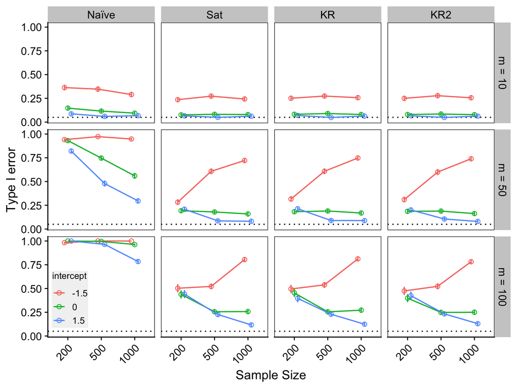

# Power

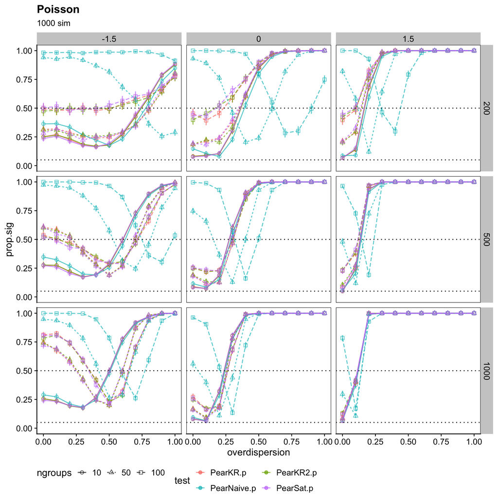

- Power for the 3 correction methods is basically the same.
- Corrected power still very bad for small intercepts (-1.5 and 0),

Figure for each N groups separated

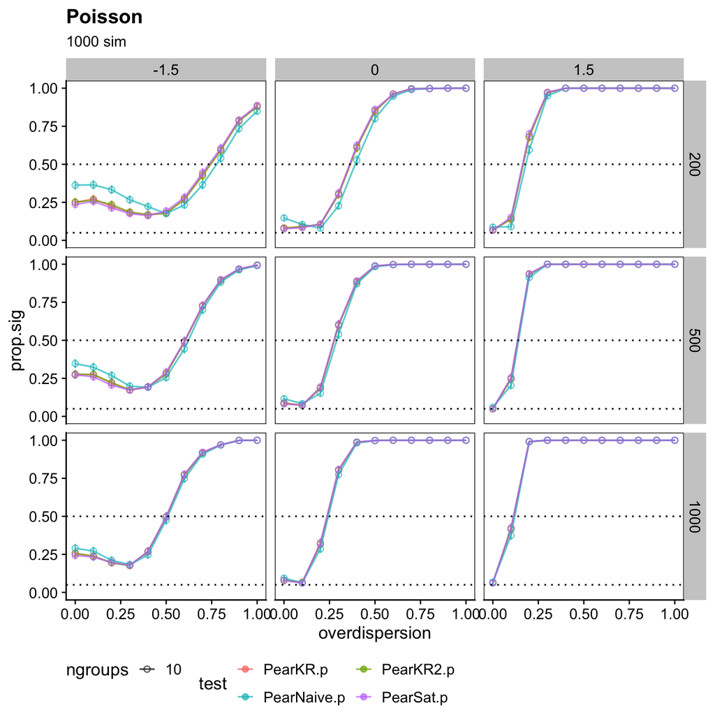

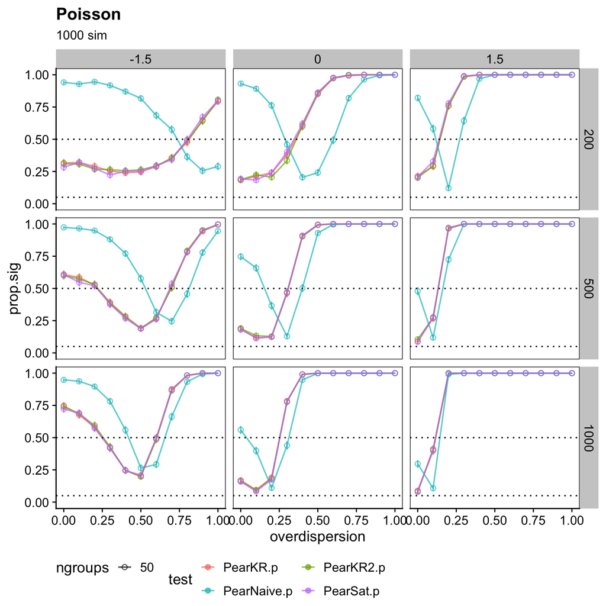

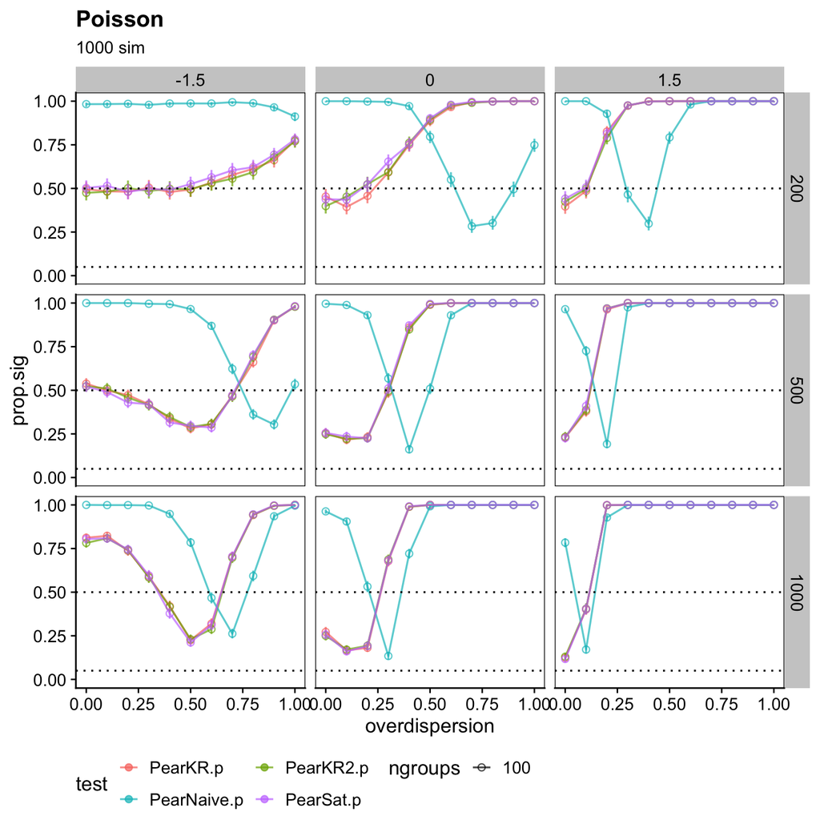

# Dispersion statistics

Median of disp stat

```r
d.pois <- simuls.pois2 %>% dplyr::select(ends_with("dispersion"), replicate, ngroups,
                                        overdispersion, intercept, sampleSize) %>%
  pivot_longer(1:4, names_to = "test", values_to = "dispersion") %>%
  group_by(sampleSize, ngroups, intercept,overdispersion, test) %>%
  summarise(median.stat = median(dispersion, na.rm=T),
            mcse = mcse_median(dispersion))
```

[output not shown]

```r
d.pois$intercept <- fct_relevel(d.pois$intercept, "-1.5", "0", "1.5")
d.pois$ngroups <- fct_relevel(d.pois$ngroups, "10", "50", "100")
d.pois$sampleSize <- as.factor(as.numeric(d.pois$sampleSize))
```

[figure not shown]

Simplified figure with just one correction (KR2) to compare with the Naïve

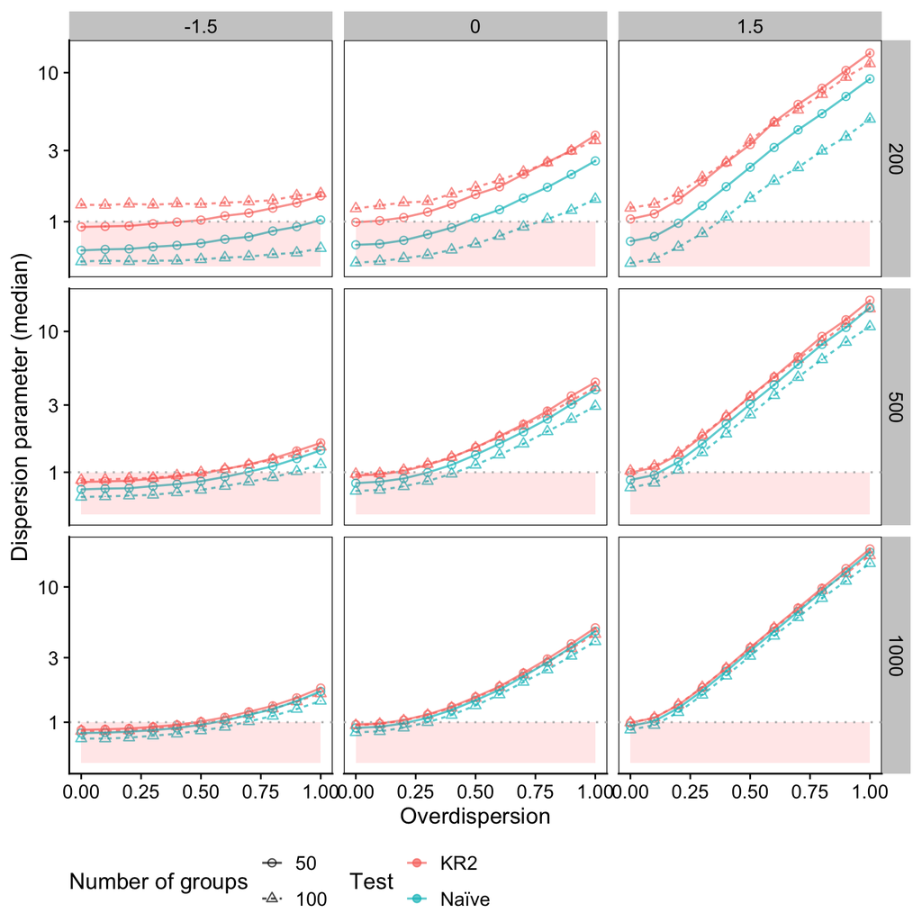

# Compare power with the other tests

Compare pearson corrections with Dharma-conditional and pearson par boot.

```r
load(here("data", "5_glmmPois_power_50.Rdata")) # simulated data
out.pois50 <- out.pois
load(here("data", "5_glmmPois_power_100.Rdata")) # simulated data
out.pois100 <- out.pois

out.pois <- flatten(list(out.pois50, out.pois100))

simuls.pois <- map_dfr(out.pois, "simulations", .id="model") %>%
  separate(model, c("ngroups", "sampleSize", "intercept"), sep="_") %>%
  rename("overdispersion" = "controlValues")

# power
pw <- simuls.pois %>% dplyr::select(dhaCO.p.val,refCO.p.val, replicate,
                                      ngroups,
                                      overdispersion, intercept, sampleSize) %>%
  filter(intercept %in% c( "-1.5", "0", "1.5"),
         sampleSize %in% c("200", "500", "1000")) %>%
  pivot_longer(1:2, names_to = "test", values_to = "p.val") %>%
  group_by(sampleSize, ngroups, intercept, overdispersion, test) %>%
  summarise(p.sig = sum(p.val<0.05,na.rm=T),
            nsim = length(p.val[!is.na(p.val)]))
```

[output not shown]

```r
pw$prop.sig <- pw$p.sig/pw$nsim
# binom.test: Monte Carlo CI for the proportion of significant tests
for (i in 1:nrow(pw)) {
  btest <- binom.test(pw$p.sig[i], n=pw$nsim[i], p=0.05)
  pw$p.bin0.05[i] <- btest$p.value
  pw$conf.low[i] <- btest$conf.int[1]
  pw$conf.up[i] <- btest$conf.int[2]
}
pw$intercept <- fct_relevel(pw$intercept, "-1.5", "0", "1.5")
pw$sampleSize <- as.factor(as.numeric(pw$sampleSize))
```

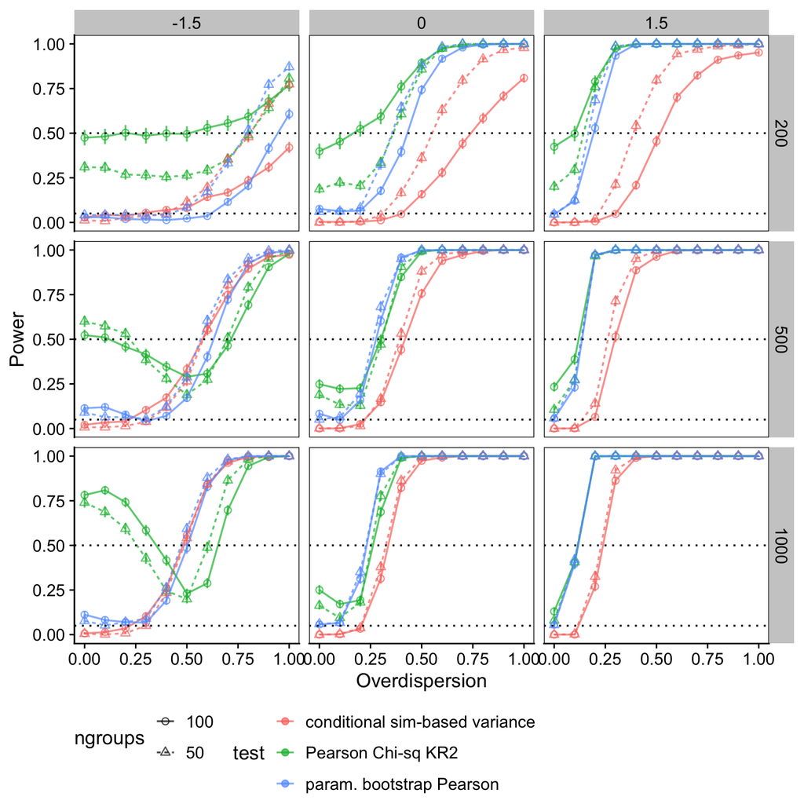

```r
comb <- p.pois %>% filter(ngroups %in% c("50", "100"), test == "PearKR2.p") %>%
  bind_rows(pw)

ggplot(comb, aes(x=overdispersion, y=prop.sig, col=test, linetype=ngroups, shape=ngroups))+
  geom_point(alpha=0.7) + geom_line(alpha=0.7) +
  scale_shape_manual(values = c(1, 2, 0)) +
  geom_errorbar(aes(ymin=conf.low, ymax=conf.up),
                alpha=0.7,
                width = 0,
                linetype = "solid",
                show.legend = FALSE) +
  facet_grid(sampleSize~intercept) +
  geom_hline(yintercept = c(0.05,0.5), linetype="dotted") +
  ylim(0,1)+
  theme(panel.background = element_rect(color="black"),
        legend.position = "bottom") +
  guides(color=guide_legend(nrow=3, byrow=TRUE),
         linetype=guide_legend(nrow=2, byrow=TRUE),
         shape=guide_legend(nrow=2, byrow=TRUE)) +
  xlab("Overdispersion") + ylab("Power")+
  scale_color_discrete(labels = c("conditional sim-based variance",
                                   "Pearson Chi-sq KR2",
                                   "param. bootstrap Pearson"))
```

```r
ggsave(here("figures", "8_glmm_approxDF_power2.pdf"), width=8, height = 8)
```